# Figure 6

John Favate

2021-01-12 10:41:47

Figure 6 contains the KEGG and PPS results

```r
# Prevent printing of warnings and such in the HTML
knitr::opts_chunk$set(warning = FALSE, message = FALSE)
```

```r
library(tidyverse)
library(corrr)
library(patchwork)
library(ggpubr)
library(ggrepel)

all.data <- read_csv("../../data_frames/all_data.csv")

# mutator order and colors
mut.levels <- all.data %>%
  select(line, mutator) %>%
  arrange(mutator, line) %>%
  unique() %>%
  pull(line)

mut.colors <- c("black", rep("black", 5), rep("firebrick3", 5))
```

### Panel A

Heatmap of KEGG scores

```r
kegg.df <- read_csv("../../data_frames/table_s11_kegg_results.csv")

head(kegg.df)
```

| line | seqtype | id | description | setsize | enrichmentscore | nes | pvalue | p.adjust | qvalues | rank | leading_edge | core_enrichment |
| --- | --- | --- | --- | --- | --- | --- | --- | --- | --- | --- | --- | --- |
| Ara-1 | ribo | ebr02040 | Flagellar assembly | 23 | -0.9752978 | -2.251342 | 9.304599e-18 | 1.107247e-15 | 9.304599e-16 | 41 | tags=74%, list=1%, signal=74% | ECB_01849/ECB_01069/ECB_01850/ECB_01066/ECB_01068/ECB_01079/ECB_01851/ECB_01071/ECB_01070/ECB_01067/ECB_01073/ECB_01072/ECB_01074/ECB_01078/ECB_01076/ECB_01077/ECB_01075 |
| Ara-1 | ribo | ebr03010 | Ribosome | 55 | 0.7277091 | 2.286115 | 1.300370e-08 | 7.737204e-07 | 6.501852e-07 | 841 | tags=73%, list=21%, signal=59% | ECB_03821/ECB_03494/ECB_03157/ECB_03493/ECB_03148/ECB_02115/ECB_04067/ECB_03586/ECB_01686/ECB_04070/ECB_03192/ECB_03156/ECB_03147/ECB_03171/ECB_03158/ECB_03172/ECB_03167/ECB_03170/ECB_03090/ECB_03091/… |
| Ara-1 | ribo | ebr00240 | Pyrimidine metabolism | 51 | 0.7013478 | 2.189083 | 6.070787e-07 | 2.408079e-05 | 2.023596e-05 | 655 | tags=41%, list=16%, signal=35% | ECB_04113/ECB_00036/ECB_04112/ECB_02390/ECB_00291/ECB_03499/ECB_00037/ECB_02410/ECB_00914/ECB_00949/ECB_02160/ECB_00169/ECB_01258/ECB_04085/ECB_04249/ECB_02640/ECB_03251/ECB_02625/ECB_04260/ECB_02089/… |
| Ara-1 | ribo | ebr02010 | ABC transporters | 183 | -0.5506228 | -1.750609 | 1.380166e-05 | 4.105993e-04 | 3.450414e-04 | 451 | tags=27%, list=11%, signal=25% | ECB_00150/ECB_02233/ECB_00557/ECB_00556/ECB_01267/ECB_00196/ECB_02232/ECB_03609/ECB_02127/ECB_00797/ECB_03612/ECB_01217/ECB_01867/ECB_00317/ECB_01454/ECB_04153/ECB_02231/ECB_02060/ECB_00555/ECB_03544/… |
| Ara-1 | ribo | ebr00630 | Glyoxylate and dicarboxylate metabolism | 42 | 0.6937472 | 2.076084 | 1.993785e-05 | 4.745207e-04 | 3.987569e-04 | 466 | tags=33%, list=11%, signal=30% | ECB_02737/ECB_03755/ECB_02735/ECB_03941/ECB_02736/ECB_02692/ECB_03887/ECB_01370/ECB_03886/ECB_03778/ECB_00117/ECB_03777/ECB_02443/ECB_01253 |
| Ara-1 | ribo | ebr01200 | Carbon metabolism | 111 | 0.4915708 | 1.741847 | 1.674769e-04 | 2.921355e-03 | 2.454920e-03 | 937 | tags=40%, list=23%, signal=31% | ECB_00682/ECB_02737/ECB_02735/ECB_03941/ECB_02736/ECB_02642/ECB_00681/ECB_02692/ECB_04264/ECB_03887/ECB_00479/ECB_03886/ECB_01581/ECB_00683/ECB_03810/ECB_03778/ECB_00117/ECB_02354/ECB_00684/ECB_02083/… |

```r
sig.terms <- kegg.df %>%
  filter(seqtype == "rna") %>%
  filter(qvalues <= .05) %>%
  group_by(description) %>%
  tally() %>%
  ungroup() %>%
  filter(n >= 4 & !is.na(description)) %>%
  pull(description)
```

Order the terms by mean enrichment score across the lines, this makes an ordered vector where the ends are the top up and down pathways.

```r
# decide the order
term.order <- kegg.df %>%
  filter(description %in% sig.terms) %>%
  group_by(description, seqtype) %>%
  summarise(mean.es = mean(enrichmentscore)) %>%
  filter(seqtype == "rna") %>%
  arrange(mean.es) %>%
  pull(description)

# get the top terms
top.terms <- c(head(term.order, 6), tail(term.order, 6))
```

Factor the data frame by various metrics to enforce axis order.

```r
kegg.df$description <- factor(kegg.df$description, levels = rev(term.order))

kegg.df$line <- factor(kegg.df$line, levels = mut.levels)

kegg.df$seqtype <- factor(kegg.df$seqtype, levels= c("rna", "ribo"))
```

Plot

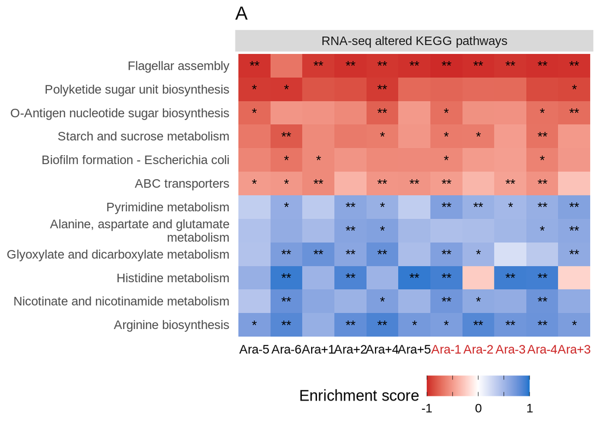

```r
fac.labs <- c("rna" = "RNA-seq altered KEGG pathways", "ribo" = "Ribo-seq")

pa <- kegg.df %>%
  filter(description %in% top.terms & seqtype == "rna") %>%
  mutate(sigstar = ifelse(qvalues <= .01, "**", ifelse(qvalues <= .05, "*", ""))) %>%
  ggplot(., aes(line, description, fill = enrichmentscore, label = sigstar))+
  geom_raster()+
  scale_fill_gradientn(name = "Enrichment score",
                       colors = c("firebrick3", "white", "dodgerblue3"),
                       breaks = seq(-1, 1, .5),
                       labels = c(-1, "", 0, "", 1),
                       limits = c(-1, 1),
                       guide = guide_colorbar(ticks.colour = "black"))+
  geom_text()+
  theme(legend.position = "bottom")+
  labs(x = NULL, y = NULL, title = "A")+
  theme(panel.background = element_blank(),
        axis.ticks = element_blank(),
        text = element_text(size = 13),
        axis.text.x = element_text(color = mut.colors))+
  facet_wrap(~ seqtype, labeller = as_labeller(fac.labs))+
  scale_y_discrete(labels = scales::label_wrap(width = 40))

pa
```

### Panel B

The PPS section, load the PPS data frame

```r
pps.df <- read_csv("../../data_frames/table_s12_pps_scores.csv")
```

Remove some odd characters

```r
pps.df$common_name <- gsub("<i>N<\\/i>", "N", pps.df$common_name) %>%
  gsub("<i>O<\\/i>", "O", .) %>%
  gsub("(<i>E. coli<\\/i>)", "", .) %>%
  gsub("\\(\\)", "", .)
```

Determine the top the top n pathways by looking at mean PPS across lines

```r
path.order <- pps.df %>%
  filter(type == "actual" & seqtype == "rna") %>% # only the actual PPS for RNAseq
  group_by(common_name) %>%                       # for each pathway
  summarise(mean_pps = mean(pps)) %>%             # calc mean pps
  ungroup() %>%                                   #
  arrange(desc(mean_pps)) %>%                     # order pathways by decreasing PPS
  pull(common_name)                               # get pathway identifier
```

Pick the top n pathways to display and create a data frame for graphing

```r
tops <- path.order[1:10]

bdf <- pps.df %>%
  filter(seqtype == "rna" & type == "actual" & common_name %in% tops) %>% # pick those top pathways for RNAseq
  mutate(common_name = factor(common_name, levels = tops))                # factor so they appear in order of inc PPS

head(bdf)
```

| seqtype | line | pathway | pps | type | iteration | common_name |
| --- | --- | --- | --- | --- | --- | --- |
| rna | Ara+2 | PWY-5340 | 11.979882 | actual | real | sulfate activation for sulfonation |
| rna | Ara-5 | PWY-5340 | 9.379543 | actual | real | sulfate activation for sulfonation |
| rna | Ara+2 | SO4ASSIM-PWY | 8.799409 | actual | real | sulfate reduction I (assimilatory) |
| rna | Ara+2 | PWY-6772 | 7.396003 | actual | real | hydrogen production V |
| rna | Ara-5 | SO4ASSIM-PWY | 6.729486 | actual | real | sulfate reduction I (assimilatory) |
| rna | Ara+3 | PWY-6772 | 5.866942 | actual | real | hydrogen production V |

Graph them

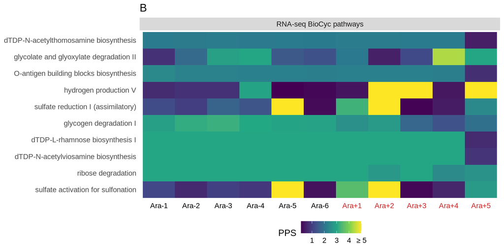

```r
b.labs <- c("0", "1", "2", "3", "4", paste("\u2265", 5))

pb <- bdf %>%
  mutate(newpps = ifelse(pps > 5, 5, pps),
         faclab = "RNA-seq BioCyc pathways") %>%
  ggplot(., aes(line, common_name, fill = newpps))+
  geom_raster()+
  theme(legend.position = "bottom")+
  labs(x = NULL, y = NULL, title = "B")+
  theme(panel.background = element_blank(),
        axis.ticks = element_blank(),
        text = element_text(size = 13),
        axis.text.x = element_text(color = mut.colors))+
  scale_fill_viridis_c(option = "D", name = "PPS", labels = b.labs)+
  scale_y_discrete(labels = scales::label_wrap(width = 40))+
  facet_wrap(~faclab)

pb
```

### Panel C

Line to line correlations of KEGG scores in each line. This will compare among categories that were significant in any line.

```r
# get the id of any sig category
sig.keggs <- kegg.df %>%
  filter(qvalues <= .01) %>%
  pull(id) %>%
  unique()

# create the df for the plot
cdf <- kegg.df %>%
  filter(id %in% sig.keggs) %>%                                # only use that set of ids
  select(line, id, seqtype, enrichmentscore) %>%               # keep these cols
  pivot_wider(names_from = line,                               # reshape to cols of pathway, lines, cells of kegg scores
              values_from = enrichmentscore) %>%               #
  select(-id) %>%                                              # remove this column
  split(.$seqtype) %>%                                         # for each seqtype
  map(function(x){                                             #
    x %>%                                                      #
      select(-seqtype) %>%                                     # remove this column
      correlate(diagonal = NA, method = "spearman") %>%        # make correlation matrix
      shave() %>%                                              # remove redundant entries, the diaganol
      pivot_longer(cols = starts_with("Ara"),                  # reshape to line1, line2, rs
                   values_to = "rs",                           #
                   names_to = "line") %>%                      #
      filter(!is.na(rs))                                       # remove NAs
  }) %>%                                                       #
  bind_rows(.id = "seqtype") %>%                               # combine to one data frame
  mutate(seqtype = factor(seqtype, levels = c("rna", "ribo"))) # order so rna comes first
```

A plot

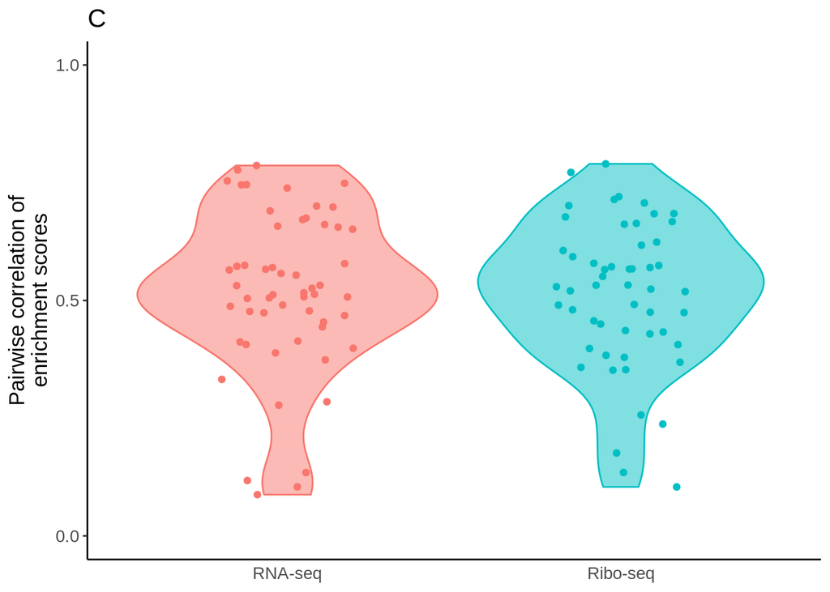

```r
pc <- ggplot(cdf, aes(x = seqtype, y = rs, fill = seqtype, color = seqtype))+
  geom_violin(alpha = .5)+
  geom_jitter(height = 0, width = .2)+
  scale_y_continuous(limits = c(0,1), breaks = c(0, .5, 1))+
  theme_classic()+
  theme(text = element_text(size = 13),
        axis.ticks.x = element_blank())+
  labs(x = NULL,
       y = "Pairwise correlation of\nenrichment scores",
       title = "C")+
  guides(fill = FALSE)+
  scale_x_discrete(labels = c("RNA-seq", "Ribo-seq"))+
  scale_color_discrete(guide = FALSE)+
  scale_fill_discrete(guide = FALSE)

pc
```

### Panel D

A figure that shows that PPS scores for lines are correlated.

```r
pps.cors <- pps.df %>%
  split(list(.$type, .$iteration, .$seqtype), drop = TRUE) %>%            # separate by these
  map(function(x){                                                        #
    x %>%                                                                 #
      select(-seqtype, -type, -iteration, -common_name) %>%               # only retain these columns
      pivot_wider(., names_from = line, values_from = pps) %>%            # reshape to rows of pathways, cols of lines, cells of pps
      select(-pathway) %>%                                                # remove the pathway col
      correlate(diagonal = NA, method = "spearman") %>%                   # make correlation matrix
      shave() %>%                                                         # remove the redundant entries
      pivot_longer(., cols = starts_with("Ara"),                          # reshape to line1, line2, rs
                   values_to = "rs",                                      #
                   names_to = "line") %>%                                 #
      filter(!is.na(rs))                                                  # get rid of NAs, the diagonal
  }) %>%                                                                  #
  bind_rows(.id = "sample") %>%                                           # bind to one df
  separate(sample, into = c("type", "iteration", "seqtype"), sep = "\\.") # separate this column to three more

# factor so rna comes first
pps.cors$seqtype <- factor(pps.cors$seqtype, levels = c("rna", "ribo"))

head(pps.cors)
```

| type | iteration | seqtype | rowname | line | rs |
| --- | --- | --- | --- | --- | --- |
| random | 1 | ribo | Ara-2 | Ara-1 | 0.2143815 |
| random | 1 | ribo | Ara-3 | Ara-1 | 0.1585031 |
| random | 1 | ribo | Ara-3 | Ara-2 | 0.1564737 |
| random | 1 | ribo | Ara-4 | Ara-1 | 0.2314308 |
| random | 1 | ribo | Ara-4 | Ara-2 | 0.1891321 |
| random | 1 | ribo | Ara-4 | Ara-3 | 0.2292347 |

These are statistically different, but it won’t let me change that to p<.01 on the graph

```r
compare_means(formula = rs ~ type, data = pps.cors, group.by = "seqtype", method = "t.test")
```

| seqtype | .y. | group1 | group2 | p | p.adj | p.format | p.signif | method |
| --- | --- | --- | --- | --- | --- | --- | --- | --- |
| ribo | rs | random | actual | 4.202484e-29 | 8.4e-29 | <2e-16 | **** | T-test |
| rna | rs | random | actual | 2.592663e-28 | 2.6e-28 | <2e-16 | **** | T-test |

The plot with altered labels

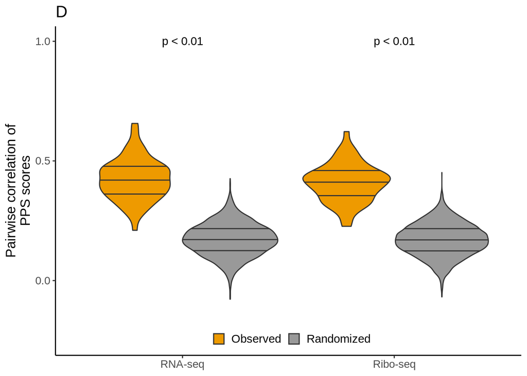

```r
pd <- pps.cors %>%
  ggplot(., aes(seqtype, rs, fill = type))+
  geom_violin(draw_quantiles = c(.25, .5, .75))+
  scale_y_continuous(limits = c(-.25, 1), breaks = c(0, .5, 1))+
  scale_fill_manual(values = c("orange2", "grey60"), name = NULL, labels = c("Observed", "Randomized"))+
  theme_classic()+
  theme(text = element_text(size = 13),
        legend.position = c(.5, .05),
        legend.background = element_blank(),
        legend.direction = "horizontal",
        legend.text = element_text(size = 11),
        legend.key.size = unit(4, "mm"))+
  labs(x = NULL,
       y = "Pairwise correlation of\nPPS scores",
       title = "D")+
  scale_x_discrete(labels = c("RNA-seq", "Ribo-seq"))+
  annotate("text", label = "p < 0.01", x = 1, y = 1)+
  annotate("text", label = "p < 0.01", x = 2, y = 1)

pd
```

### Final figure construction

The top row

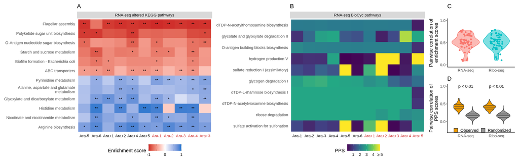

```r
left <- pa | pb

right <- pc / pd

(ff <- (left | right) + plot_layout(widths = c(.4,.4, .2), ncol = 3))
```

Save it

```r
ggsave(ff, filename = "../../figures/g_fig_6.pdf", width = 19, height = 6, device = cairo_pdf)

ggsave(ff, filename = "../../figures/g_fig_6.png", width = 19, height = 6, dpi = 300)
```